# Frog Finder

Patricia Haden for Otago Zoology

02/09/2020

# Introduction

Project **frog_finder_R** contains R source code to match a target image (e.g. of a frog’s eye) to a set of standard images, using scale and rotation-invariant feature matching (Lowe, 2004; see code for details). The algorithm produces a measure of match quality for each standard image, and identifies the best-matching standard. Matches can be made against a single target image, or simultaneously against a folder of target images. Results are returned in a data frame for easy data manipulation. Examples of use can be found in this document and in file **frog_finder_examples.R** in the project folder.

The core functions are in file **frog_finder.R**. The primary end-user function is **match_targets** (see below for usage instructions).

The project also contains a tool to allow easy image cropping from inside RStudio (file **image_cropper.R**), and a GUI tool for convenient identification of single images without the need to write any code (file **app.R**).

# Image File Naming Protocol

Standard image files should be named **xxx_y_z.png** where:

- xxx is a unique three digit identifier for the frog
- y is a one character tag distinguishing multiple images of the same frog
- z can be any legal string of characters
- underscores (_) are literal
- .png is the file suffix. This is the preferred file type for matching.

See the included sample image files for examples. The tool will still work if this naming protocol is violated, but the frog IDs in the output, which are derived from the image file names, may not be sensible.

# Matching Images to Identify Targets

To match targets to standards, use function **match_targets**.

Usage is **match_targets(targets, standards, ratio, best_only = TRUE)**

## Example

Assume that the R project folder contains a file **005_b_field.png** (for illustration only), a folder **frogEyeTestImages** containing images to be identified, and a folder **frogEyeStandardImages** containing a single good eye image for each known frog. (Input files are not required to be inside the project folder, but other locations must be specified with complete file paths). The following code shows various options for identifying the target images.

```r
# Get access to function match_targets
source("frog_finder.R")

# Control algorithm sensitivity. Standard value is 0.6. Raise to make matching easier
ratio <- 0.6

# Define variables for readable code
target_image_file <- "005_b_field.png"
target_image_directory <- "frogEyeTestImages"
std_image_directory <- "frogEyeStandardImages"

#============================================================================================
# Get best match(es) by providing target, standards, and ratio. Pass either a single
# target image, or a folder containing multiple target images.
#============================================================================================

# Match a single target image. Returns a one-line data frame with the best match for the target.
best_match_single_target <- match_targets(target_image_file, std_image_directory, ratio )
print(best_match_single_target)
```

```
##   Target Standard MatchQual                                   StdImg
## 1  005_b    005_a 0.1666667 frogEyeStandardImages/005_a_standard.png
```

```r
# Match a directory containing multiple target images. (Allow some time for large numbers of images.)
# Returns a multi-line data frame with the best match for each target image in the folder.
best_match_multiple_targets <- match_targets(target_image_directory, std_image_directory, ratio )
head(best_match_multiple_targets) # displaying only the first few rows
```

```
##   Target Standard MatchQual                                   StdImg
## 1  001_a    001_a 0.0000000 frogEyeStandardImages/001_a_standard.png
## 2  001_b    001_a 0.1818182 frogEyeStandardImages/001_a_standard.png
## 3  001_s    001_a 0.0000000 frogEyeStandardImages/001_a_standard.png
## 4  002_a    002_a 0.1666667 frogEyeStandardImages/002_a_standard.png
## 5  002_b    002_a 0.1842105 frogEyeStandardImages/002_a_standard.png
## 6  002_c    001_a 0.0000000 frogEyeStandardImages/001_a_standard.png
```

```r
#============================================================================================
# Get match quality scores against all standard images by setting best_only to FALSE. Pass
# either a single target image, or a folder containing multiple target images.
#============================================================================================

# A single target image. Returns a multi-line data frame with the match quality for each standard.
all_match_single_target <- match_targets(target_image_file, std_image_directory, ratio, best_only = FALSE )
print(all_match_single_target)
```

```
##   Target Standard MatchQual                                   StdImg
## 1  005_b    005_a 0.1666667 frogEyeStandardImages/005_a_standard.png
## 2  005_b    001_a 0.0000000 frogEyeStandardImages/001_a_standard.png
## 3  005_b    002_a 0.0000000 frogEyeStandardImages/002_a_standard.png
## 4  005_b    003_a 0.0000000 frogEyeStandardImages/003_a_standard.png
## 5  005_b    004_a 0.0000000 frogEyeStandardImages/004_a_standard.png
## 6  005_b    006_a 0.0000000 frogEyeStandardImages/006_a_standard.png
```

```r
# A directory containing multiple target images. (Note that this can take a while for large numbers of images.)
# Returns a multi-line data frame with n_targets x n_standards rows.
all_match_multiple_targets <- match_targets(target_image_directory, std_image_directory, ratio, best_only = FALSE )
head(all_match_multiple_targets) # displaying only the first few rows
```

```
##   Target Standard MatchQual                                   StdImg
## 1  001_a    001_a         0 frogEyeStandardImages/001_a_standard.png
## 2  001_a    002_a         0 frogEyeStandardImages/002_a_standard.png
## 3  001_a    003_a         0 frogEyeStandardImages/003_a_standard.png
## 4  001_a    004_a         0 frogEyeStandardImages/004_a_standard.png
## 5  001_a    005_a         0 frogEyeStandardImages/005_a_standard.png
## 6  001_a    006_a         0 frogEyeStandardImages/006_a_standard.png
```

```r
# Save your output for further processing
write.csv(all_match_multiple_targets, "frog_finder_demo_output.csv")
```

# Using the GUI to match a single target

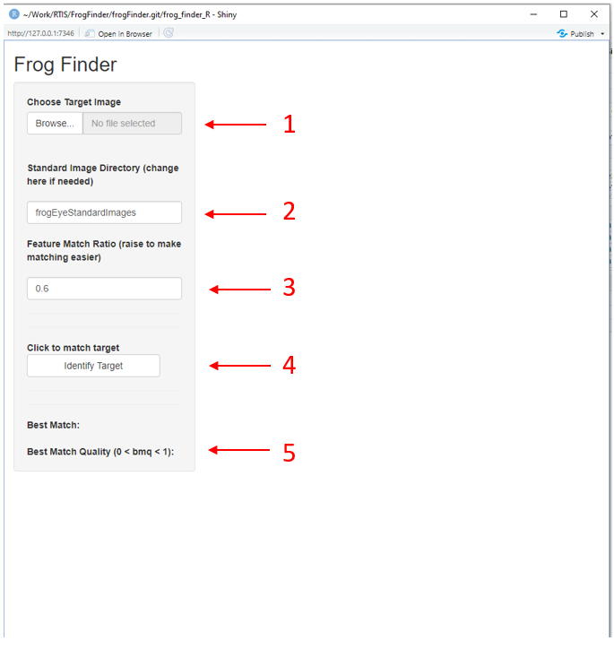

Frog Finder GUI on open (red arrows and numbers refer to steps described below)

## Using the controls in the left side panel:

1. Select a target image. Click the “Browse” button and navigate to the image you wish to match. The image appears in the right-hand pane.
2. Type the name of the standard image directory into the indicated text box (the default name is frogEyeStandardImages)
3. Adjust the ratio term if desired (the default value is 0.6). Spin arrows will appear when you mouse over the box containing “0.6”
4. Click the “Identify Target” button to perform the match.
5. Information about the best matching standard image appears at the bottom of the side panel.

[figure not shown]

Frog Finder GUI after matching

# Using the Image Cropper

Frog Finder will be most accurate when presented with images of just the animal’s eye, not the entire frog. Images can be cropped in any photo editing tool (e.g. Paint, Photoshop, etc.), but for convenience, the **frog_finder.R** project contains code to allow simple rectangular cropping directly inside RStudio. The file **image_cropper.R** contains a function **image_cropper** which accepts an image file name. When the function is called, the image appears in the RStudio Plot pane, and the words “Select the two opposite corners of a rectangle on the plot.” appear in the RStudio console. Click the mouse at the upper-left and lower-right points of the frog’s eye area. The output image will automatically be saved to the package directory. It will have the same name as the target image with “cropped” as a prefix.

[figure not shown]

Before clicking the corner points

[figure not shown]

After clicking the corner points

```r
#############################################################
# To crop images in the Plot pane
#############################################################

# Installing the package is required once on each computer.
# install.packages("ShinyImage")

# Load the required library.
library("ShinyImage")

# Load the code
source("image_cropper.R")

# Prepare the image file variable for tidy code
target_file_name <- "frog.jpg"

# Call the function. The cropped image is saved automatically. The functions
# returns the file name of the new image in case you need it.
cropped_target_file_name <- image_cropper(target_file_name)
```

# Assessing Match Accuracy

Identification accuracy is highly dependent on the quality of the target and standard images. To test identification accuracy, perform a “best_only” matching on a set of target images whose identity is known. Pass the results to function **match_accuracy**. The function outputs the percent correct matches, and the associated confusion matrix. **NB: Function match_accuray requires both the target and standard images to follow the image-naming protocol described above.**

```r
# Load the code file
source("frog_finder.R")

# Run match_targets as above
ratio <- 0.6 # Standard value is 0.6. Raise to make matching easier
target_image_directory <- "frogEyeTestImages"
std_image_directory <- "frogEyeStandardImages"
best_match_multiple_targets <- match_targets(target_image_directory, std_image_directory, ratio )

# Pass to match_accuracy.
accuracy_test <- match_accuracy(best_match_multiple_targets)

# The result is a list with two fields -- percent correct (PerCorrIDs) and the
# identification confusion matrix (ConfMatrix). A nice output can be achieved as follows:

print(paste("Percent correct identifications:", accuracy_test$PercCorrIds))
```

```
## [1] "Percent correct identifications: 0.833333333333333"
```

```r
print("Identification Confusion Matrix:")
```

```
## [1] "Identification Confusion Matrix:"
```

```r
print(accuracy_test$ConfMatrix)
```

```
##           std_ids
## target_ids 1 2 3 4 5 6
##          1 3 0 0 0 0 0
##          2 1 2 0 0 0 0
##          3 2 0 1 0 0 0
##          4 0 0 0 3 0 0
##          5 0 0 0 0 3 0
##          6 0 0 0 0 0 3
```

# References

Lowe, D.G. Distinctive Image Features from Scale-Invariant Keypoints. *International Journal of Computer Vision* 60, 91–110 (2004)